# Simulation paper– GLM, Case-crossover, or Cross-year models for climate-related epidemiology

Brooke Anderson

November 12, 2015

# Methods

## Generating the simulated data

### Exposure data

There are several different possible ways to generate the simulated exposure data (or to pull in observed data to use for this).

For all of the simulated exposure series, this starts by specifying the number of days to simulate, `n`:

```r
n <- 1000
```

#### Binary exposure

For a binary exposure, then it’s necessary to specify the probability of exposure, `p_exp`. Then it’s pretty straightforward to generate the series of exposures:

```r
# Generate a binary exposure
p_exp <- 0.1
x <- sample(c(0, 1), size = n, replace = TRUE, prob = c(1-p_exp, p_exp))
head(x)
```

```
## [1] 0 0 0 0 0 0
```

Here’s a function that takes arguments of `n` and `p_exp` and returns a generated series (I’m also adding in a part to put in dates– unless I specify otherwise, this will default to start at Jan. 1, 2000):

```r
# Function to generate a binary exposure
binary_exposure <- function(n, p_exp, start.date = "2000-01-01", ...){
        start.date <- as.Date(start.date)
        date <- seq(from = start.date, by = 1, length.out = n)
        x <- sample(c(0, 1), size = n, replace = TRUE,
                    prob = c(1-p_exp, p_exp))
        df <- data.frame(date, x)
        return(df)
}
binary_exposure(n = 5, p_exp = 0.25)
```

```
##         date x
## 1 2000-01-01 0
## 2 2000-01-02 1
## 3 2000-01-03 0
## 4 2000-01-04 0
## 5 2000-01-05 0
```

#### Continuous exposure

For a continuous exposure (which I’ll assume it’s okay to assume is normally distributed), it’s necessary to specify the mean, `mu`, and standard deviation, `sd`, of the distribution of the exposure. Then it’s possible to simulate the data:

```r
# Generate a continuous exposure
mu <- 10 # These values are both from the Chicago NMMAPS values for
sd <- 10 # temperature in degrees Celcius
x <- rnorm(n, mean = mu, sd = sd)
head(x)
```

```
## [1]  -5.737429  12.795696   4.389262 -11.727888  11.301585  21.805342
```

```r
# Function to generate a continuous exposure
continuous_exposure <- function(n, mu, sd, start.date = "2000-01-01", ...){
        start.date <- as.Date(start.date)
        date <- seq(from = start.date, by = 1, length.out = n)
        x <- rnorm(n, mean = mu, sd = sd)
        df <- data.frame(date, x)
        return(df)
}
continuous_exposure(n = 5, mu = 10, sd = 10)
```

```
##         date         x
## 1 2000-01-01  7.843690
## 2 2000-01-02 10.592681
## 3 2000-01-03 10.213568
## 4 2000-01-04 12.476113
## 5 2000-01-05  9.227522
```

#### Generate exposure data with seasonal pattern

```r
# Generate exposure with a seasonal pattern
```

#### Pull real data

```r
# Pull exposure with a seasonal pattern
library(dlnm)
data(chicagoNMMAPS)
chic <- chicagoNMMAPS

if(n < nrow(chic)){
        start <- sample(1:(nrow(chic) - n), 1) # randomly choose a starting point
        x <- chic$temp[start:(start + n -1)]
}
head(x)
```

```
## [1] 1.388889 1.388889 2.222222 1.111111 3.333333 2.500000
```

```r
# Function to pull exposure with a seasonal pattern
# Note: Your `data` must have a column called `date` as well as one with the
# measure you specify, with that column name.
pull_exposure <- function(n, data = "chicagoNMMAPS", measure = "temp", ...){
        if(data == "chicagoNMMAPS"){
                require(dlnm)
                data(chicagoNMMAPS)
                data <- chicagoNMMAPS
        }

        data$measure <- data[ , measure]

        if(n < nrow(data)){
                # randomly choose a starting point
                start <- sample(1:(nrow(data) - n), 1)
                df <- data[start:(start + n - 1), c("date", measure)]
        } else{
                stop("You asked for too many simulated observations given the dataset you're pulling the data from. Try a smaller value of n.")
        }

        return(df)
}

pull_exposure(n = 3)
```

```
##            date     temp
## 2528 1993-12-02 5.277778
## 2529 1993-12-03 2.222222
## 2530 1993-12-04 3.888889
```

```r
pull_exposure(n = 3)
```

```
##           date      temp
## 774 1989-02-12 -3.055556
## 775 1989-02-13  0.000000
## 776 1989-02-14 -2.500000
```

```r
pull_exposure(n = 3, measure = "pm10")
```

```
##           date     pm10
## 658 1988-10-19 20.30745
## 659 1988-10-20 16.24807
## 660 1988-10-21 23.23224
```

### Expected mean baseline for outcome data

#### Constant baseline hazard rate

To generate the expected mean baseline for an outcome with a constant baseline hazard rate over time, you just need to specify the $\lambda$ value for the distribution of the outcome (if you’re using a Poisson distribution):

```r
# Contant baseline of outcome
lambda <- 100 # Approximate mean value of daily deaths for chicagoNMMAPS
exp_base_y <- rep(lambda, n)
```

```r
constant_baseline <- function(n, lambda, start.date = "2000-01-01", ...){
        start.date <- as.Date(start.date)
        date <- seq(from = start.date, by = 1, length.out = n)
        exp_base_y <- rep(lambda, n)
        df <- data.frame(date = date,
                         exp_base_y = exp_base_y)
        return(df)
}
constant_baseline(n = 3, lambda = 100)
```

```
##         date exp_base_y
## 1 2000-01-01        100
## 2 2000-01-02        100
## 3 2000-01-03        100
```

#### Baseline hazard rate varies by season

```r
# Baseline risk of outcome varies by season
```

```r
# Baseline risk of outcome varies over years

# Baseline risk of outcome varies by season and over years

# Outcome with mortality displacement

# Outcome with delayed, slightly elevated risk
```

### Simulated outcome data

Moving from the expected value of the baseline outcome to simulated outcome data requires a few things. First, it’s necessary to specify the true effect associated with the exposure:

```r
# Specify true effect
rr <- 1.2
```

Then, it’s necessary to combine the exposure, `x`, and expected baseline outcome values, `exp_base_y`, in a dataframe:

```r
n <- 1000
p_exp <- 0.25
lambda <- 100

x <- binary_exposure(n = n, p_exp = p_exp)
exp_base_y <- constant_baseline(n = n, lambda = lambda)
df <- full_join(x, exp_base_y, by = "date")
```

Then you can generate the `exp_y` using the equation:

$$E(log(\mu_t)) = \beta_0 + \beta_1X_1$$

(For this, it will be important that the relative risk is specified for a **one-unit** increase in the exposure value.)

```r
df <- mutate(df, exp_y = exp(log(exp_base_y) + log(rr) * x))
```

Now, you need to decide on how the outcome data is distributed around the expected value. This is simulating outcome values from a Poisson distribution using `rpois`.

```r
# Simulate outcome data
df$y <- sapply(df$exp_y, FUN = function(x) rpois(1, x))
head(df, 3)
```

```
##         date x exp_base_y exp_y   y
## 1 2000-01-01 1        100   120 130
## 2 2000-01-02 0        100   100  98
## 3 2000-01-03 0        100   100  88
```

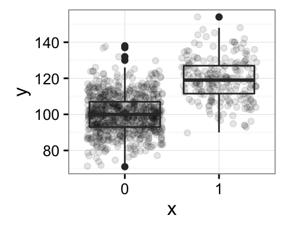

```r
to_plot <- mutate(df, x = as.factor(x))
ggplot(to_plot, aes(x = x, y = y)) +
        geom_point(position = position_jitter(), alpha = 0.1) +
        geom_boxplot( fill = NA) +
        theme_bw()
```

```r
group_by(df, exp_y) %>% summarize(mean_y = mean(y))
```

```
## Source: local data frame [2 x 2]
##
##   exp_y   mean_y
##   (dbl)    (dbl)
## 1   100 100.2651
## 2   120 119.1570
```

Here is a function to do all this:

```r
sim_data <- function(n, rr, x_type = "binary", baseline = "constant",
                     start.date = "2000-01-01", ...){

        require(dplyr)

        if(x_type == "binary"){
                x <- binary_exposure(n = n, ...)
        } else if(x_type == "continuous"){
                x <- continuous_exposure(n = n, ...)
        }

        if(baseline == "constant"){
                exp_base_y <- constant_baseline(n = n, ...)
        }

        df <- full_join(x, exp_base_y, by = "date") %>%
                mutate(exp_y = exp(log(exp_base_y) + log(rr) * x))
        df$y <- sapply(df$exp_y, FUN = function(x) rpois(1, x))

        return(df)

}
```

Here are some examples of this function:

```r
sim_data(n = 3, rr = 1.2, p_exp = .2, lambda = 100)
```

```
##         date x exp_base_y exp_y   y
## 1 2000-01-01 1        100   120 125
## 2 2000-01-02 1        100   120  99
## 3 2000-01-03 0        100   100  92
```

```r
sim_data(n = 3, rr = 1.02, x_type = "continuous", mu = 10, sd = 10, lambda = 100)
```

```
##         date         x exp_base_y    exp_y   y
## 1 2000-01-01  1.609968        100 103.2395 105
## 2 2000-01-02  3.182250        100 106.5045 105
## 3 2000-01-03 11.301984        100 125.0832 146
```

## Fitting the models

### Generalized linear model

The formula for the generalized linear model (GLM) is:

$$E(log(\mu_t)) = \beta_0 + \beta_1X_t + \mbox{ns(time, d.f.)}$$

where:

- $\mu_t$: Count of outcomes on day $t$, dispersed as a quasi-Poisson distribution
- $\beta_0$: Intercept (expected log count of health outcome when $X_t$ equals 0 and for middle of the timeframe [so `time` = 0])
- $\beta_1$: log relative risk for a 1-unit increase in exposure $X_t$
- $X_t$: Exposure on day $t$
- $\mbox{ns(time, d.f.)}$: Spline of time for $\mbox{d.f.}$ degrees of freedom per year

```r
# Fit a generalized linear model
spline_mod <- function(df, df_year = 7){
        require(splines)

        dgrs_free <- df_year * as.numeric(diff(df[c(1, nrow(df)), "date"])) / 365.4
        df$time <- scale(df$date, center = TRUE, scale = FALSE)
        mod <- glm(y ~ x + ns(time, round(dgrs_free)),
                   data = df,
                   family = quasipoisson(link = "log"))

        out_1 <- summary(mod)$coef[2, ]
        out_2 <- confint.default(mod)[2, ]
        out <- c(out_1, out_2)
        return(out)
}
```

Here are some examples of fitting this model:

```r
df <- sim_data(n = 5 * 365, rr = 1.2, p_exp = .2, lambda = 100)
spline_mod(df)
```

```
##      Estimate    Std. Error       t value      Pr(>|t|)         2.5 %
##  1.838124e-01  5.571340e-03  3.299249e+01 7.542563e-187  1.728927e-01
##        97.5 %
##  1.947320e-01
```

```r
exp(spline_mod(df)[1])
```

```
## Estimate
##  1.20179
```

```r
df <- sim_data(n = 5 * 365, rr = 1.02, x_type = "continuous",
               mu = 10, sd = 10, lambda = 100)
spline_mod(df)
```

```
##     Estimate   Std. Error      t value     Pr(>|t|)        2.5 %
## 1.993941e-02 2.107103e-04 9.462950e+01 0.000000e+00 1.952643e-02
##       97.5 %
## 2.035239e-02
```

```r
exp(spline_mod(df)[1])
```

```
## Estimate
##  1.02014
```

### Case-crossover model

Here is the formula for the case-crossover model. It’s actually using a quasi-Poisson GLM with a factor included identifying stratum (month and year):

$$E(log(\mu_t)) = \beta_0 + \beta_1X_t + \beta_2S_t$$

where:

- $\mu_t$: Count of outcomes on day $t$, assuming these outcomes follow a quasi-Poisson distribution
- $\beta_0$: Intercept (expected log count of health outcome when $X_t$ equals 0 and for the baseline level of the time strata
- $\beta_1$: log relative risk for a 1-unit increase in exposure $X_t$
- $X_t$: Exposure on day $t$
- $\beta_2$: offset for log baseline counts for each stratum
- $S_t$: Time stratum (month and year)

```r
# Fit a case-crossover model
casecross_mod <- function(df){
        df$stratum <- factor(format(df$date, "%Y.%m"))

        if (sum(df$x == 0 | df$x == 1) == length(df$x)){
                event.check <- as.matrix(table(df$stratum, df$x))
                informative.strata <- rownames(event.check)[apply(event.check,
                                                          1, prod) > 0]
                df <- subset(df, stratum %in% informative.strata)

                if(length(informative.strata) > 1){
                        mod <- glm(y ~ x + stratum,
                                   data = df,
                                   family = quasipoisson(link = "log"))
                } else {
                        mod <- glm(y ~ x,
                                   data = df,
                                   family = quasipoisson(link = "log"))
                        }
        } else {
                mod <- glm(y ~ x + stratum,
                                   data = df,
                                   family = quasipoisson(link = "log"))
        }

        out_1 <- summary(mod)$coef[2, ]
        out_2 <- confint.default(mod)[2, ]
        out <- c(out_1, out_2)
        return(out)
}
```

Here are some examples of fitting this model:

```r
df <- sim_data(n = 5 * 365, rr = 1.2, p_exp = .2, lambda = 100)
casecross_mod(df)
```

```
##      Estimate    Std. Error       t value      Pr(>|t|)         2.5 %
##  1.823016e-01  5.251765e-03  3.471244e+01 1.121031e-201  1.720083e-01
##        97.5 %
##  1.925949e-01
```

```r
exp(casecross_mod(df)[1])
```

```
## Estimate
## 1.199976
```

```r
df <- sim_data(n = 5 * 365, rr = 1.02, x_type = "continuous",
               mu = 10, sd = 10, lambda = 100)
casecross_mod(df)
```

```
##     Estimate   Std. Error      t value     Pr(>|t|)        2.5 %
## 1.993791e-02 2.145733e-04 9.291887e+01 0.000000e+00 1.951735e-02
##       97.5 %
## 2.035846e-02
```

```r
exp(casecross_mod(df)[1])
```

```
## Estimate
## 1.020138
```

### Cross-year model

$$E(log(\mu_t)) = \beta_0 + \beta_1X_t + \beta_2D_t + \beta_3Y_t$$

```r
# Fit a cross-year model
# Fit a case-crossover model
crossyear_mod <- function(df){
        df$stratum <- factor(format(df$date, "%j"))
        df$year <- factor(format(df$date, "%Y"))

        if (sum(df$x == 0 | df$x == 1) == length(df$x)){
                event.check <- as.matrix(table(df$stratum, df$x))
                informative.strata <- rownames(event.check)[apply(event.check,
                                                          1, prod) > 0]
                df <- subset(df, stratum %in% informative.strata)

                if(length(informative.strata) > 1){
                        mod <- glm(y ~ x + stratum,
                                   data = df,
                                   family = quasipoisson(link = "log"))
                } else {
                        mod <- glm(y ~ x,
                                   data = df,
                                   family = quasipoisson(link = "log"))
                        }
        } else {
                mod <- glm(y ~ x + stratum,
                                   data = df,
                                   family = quasipoisson(link = "log"))
        }

        out_1 <- summary(mod)$coef[2, ]
        out_2 <- confint.default(mod)[2, ]
        out <- c(out_1, out_2)
        return(out)
}
```

Here are some examples of applying this model:

```r
df <- sim_data(n = 5 * 365, rr = 1.2, p_exp = .2, lambda = 100)
crossyear_mod(df)
```

```
##      Estimate    Std. Error       t value      Pr(>|t|)         2.5 %
##  1.878851e-01  6.292457e-03  2.985878e+01 2.603756e-137  1.755521e-01
##        97.5 %
##  2.002181e-01
```

```r
exp(crossyear_mod(df)[1])
```

```
## Estimate
## 1.206695
```

```r
df <- sim_data(n = 5 * 365, rr = 1.02, x_type = "continuous",
               mu = 10, sd = 10, lambda = 100)
crossyear_mod(df)
```

```
##     Estimate   Std. Error      t value     Pr(>|t|)        2.5 %
## 1.951205e-02 2.370971e-04 8.229560e+01 0.000000e+00 1.904735e-02
##       97.5 %
## 1.997675e-02
```

```r
exp(crossyear_mod(df)[1])
```

```
## Estimate
## 1.019704
```

## Run lots of simulations

Now it’s pretty easy to run lots of simulations using `replicate`:

```
## stat_bin: binwidth defaulted to range/30. Use 'binwidth = x' to adjust this.
## stat_bin: binwidth defaulted to range/30. Use 'binwidth = x' to adjust this.
## stat_bin: binwidth defaulted to range/30. Use 'binwidth = x' to adjust this.
```

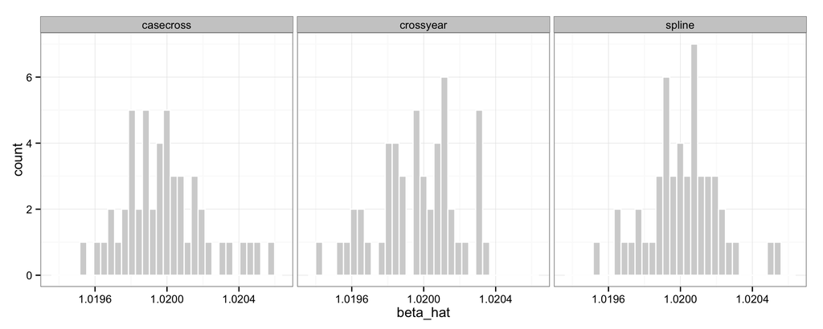

```r
n_sim <- 50
ex_spline <- replicate(n_sim, exp(spline_mod(sim_data(n = 5 * 365,
                                          rr = 1.02, x_type = "continuous",
                                          mu = 10, sd = 10, lambda = 100))[1]))

ex_casecross <- replicate(n_sim, exp(casecross_mod(sim_data(n = 5 * 365,
                                          rr = 1.02, x_type = "continuous",
                                          mu = 10, sd = 10, lambda = 100))[1]))

ex_crossyear <- replicate(n_sim, exp(crossyear_mod(sim_data(n = 5 * 365,
                                          rr = 1.02, x_type = "continuous",
                                          mu = 10, sd = 10, lambda = 100))[1]))

ex <- data.frame(beta_hat = c(ex_spline, ex_casecross, ex_crossyear),
                 model = rep(c("spline", "casecross", "crossyear"),
                             each = n_sim)) %>%
        mutate(model = factor(model))

ggplot(ex, aes(x = beta_hat)) +
        geom_histogram(fill = "lightgray", color = "white") +
        facet_wrap(~ model, ncol = 3) +
        theme_bw()
```

```r
group_by(ex, model) %>%
        summarize(mean_beta = mean(beta_hat), sd_beta = sd(beta_hat))
```

```
## Source: local data frame [3 x 3]
##
##       model mean_beta      sd_beta
##      (fctr)     (dbl)        (dbl)
## 1 casecross  1.019991 0.0002287895
## 2 crossyear  1.019963 0.0002221988
## 3    spline  1.020012 0.0001997837
```

Here is a function that will run a lot of simulations for a given dataset and model and will output a dataframe with the $\hat{\beta}$, $sd(\hat\beta)$, and p-values for the $\beta$ for each replication:

```r
rep_sims <- function(n_sims, model, n = 5 * 365, rr = 1.01,
                     x_type = "continuous", mu = 10, sd = 2, lambda = 100){
        library(dplyr)
        out <- replicate(n_sims, eval(call(model,
                                           sim_data(n = n, rr = rr,
                                                    x_type = x_type,
                                                    mu = mu, sd = sd,
                                                    lambda = lambda))))
        out <- as.data.frame(t(out))
        names(out) <- c("est", "se", "t", "p", "lower_ci", "upper_ci")
        return(out)
}
```

Here are some examples of using this function:

```r
rep_sims(n_sims = 3, model = "spline_mod")
```

```
##           est          se         t            p    lower_ci    upper_ci
## 1 0.008309762 0.001082728  7.674838 2.705755e-14 0.006187654 0.010431870
## 2 0.007603811 0.001181235  6.437172 1.559439e-10 0.005288634 0.009918989
## 3 0.011838635 0.001078604 10.975891 3.596648e-27 0.009724611 0.013952659
```

```r
rep_sims(n_sims = 3, model = "casecross_mod")
```

```
##           est          se        t            p    lower_ci   upper_ci
## 1 0.008047592 0.001109386 7.254094 6.028597e-13 0.005873235 0.01022195
## 2 0.010943878 0.001112142 9.840358 2.792522e-22 0.008764119 0.01312364
## 3 0.008992168 0.001194714 7.526631 8.255895e-14 0.006650573 0.01133376
```

```r
rep_sims(n_sims = 3, model = "crossyear_mod")
```

```
##           est          se        t            p    lower_ci   upper_ci
## 1 0.009962372 0.001273643 7.821952 9.911662e-15 0.007466078 0.01245867
## 2 0.008803797 0.001264786 6.960702 5.101933e-12 0.006324862 0.01128273
## 3 0.009782801 0.001282655 7.626993 4.311713e-14 0.007268843 0.01229676
```

## Assess performance based on simulations

All of these functions will take, as input, a dataframe of replicated simulations:

```r
rep_df <- rep_sims(n_sims = 50, model = "spline_mod", rr = 1.02)
head(rep_df, 4)
```

```
##          est          se        t            p   lower_ci   upper_ci
## 1 0.01890460 0.001076000 17.56933 7.192039e-64 0.01679568 0.02101352
## 2 0.01997802 0.001045702 19.10488 3.433265e-74 0.01792848 0.02202756
## 3 0.01992178 0.001096496 18.16859 7.923557e-68 0.01777268 0.02207087
## 4 0.02054938 0.001082786 18.97825 2.562843e-73 0.01842716 0.02267160
```

### Average estimate coefficient

This is the mean value of all the $\hat{\beta}$s over $n$ simulations (Figueiras et al. 2005). I’m also having this function calculate the mean of the $\hat{RR}$ values calculated by all the simulations.

```r
# Measure mean of estimated coefficient
mean_beta <- function(df){
        beta_hat <- mean(df$est)
        rr_hat <- mean(exp(df$est))
        out <- data.frame(beta_hat, rr_hat)
        return(out)
}
mean_beta(rep_df)
```

```
##     beta_hat   rr_hat
## 1 0.01963871 1.019833
```

### Standard deviation of estimated coefficients

This is the standard deviation of all the $\hat{\beta}$s over $n$ simulations (Figueiras et al. 2005). (In other words, I think they took all the $\hat\beta$s and took the standard deviation of all those point estimates.)

Bateson and Schwartz measure the *variance* of the estimated coefficients, instead, and they took the mean value of the variance of each of the estimated coefficients (rather than the variance across all the point estimates) (1999). In other words, I think they measured:

$$\mbox{Variance} = E(Var(\hat\beta))$$

I’ll write a function that will estimate both, `var_across_betas` to correspond with Figueiras and `mean_beta_var` to correspond with Bateson and Schwartz:

```r
# Measure standard deviation across estimated coefficient
beta_var <- function(df){
        var_across_betas <- var(df$est)
        mean_beta_var <- mean(df$se^2)
        out <- data.frame(var_across_betas, mean_beta_var)
        return(out)
}
beta_var(rep_df)
```

```
##   var_across_betas mean_beta_var
## 1     1.236963e-06  1.156846e-06
```

### % bias in estimated coefficient

Based on Figueiras and coauthors, this is measured as (2005):

$$\mbox{% bias} = 100 \frac{(\hat{\beta} - \beta)}{\beta}$$

where $\hat{\beta}$ is the mean estimated coefficient (e.g., log relative risk) over $n$ simulations.

Wang and co-authors measure *relative bias* instead (2011):

$$\mbox{% bias} = 100 \frac{(\beta - \hat{\beta})}{\beta}$$

I’ll write a function that measures both (`fig_bias` and `wang_bias`):

```r
# Measure percent bias
beta_bias <- function(df, true_rr){
        fig_bias <- 100 * (mean(df$est) - true_rr) / true_rr
        wang_bias <- 100 * (true_rr - mean(df$est)) / true_rr
        out <- data.frame(fig_bias, wang_bias)
        return(out)
}
beta_bias(rep_df, true_rr = 1.02)
```

```
##    fig_bias wang_bias
## 1 -98.07464  98.07464
```

As a note, one of these will just be the negative of the other… Does it make more sense to just take the absolute value of the difference between the two estimates and divide it by $\beta$?

### % coverage of estimated coefficients

$$\mbox{% coverage} = \mbox{% of simulations with 95% CIs that cover }\beta$$

where $\beta$ is the true value of the coefficient (e.g., log relative risk) (Figueiras et al. 2005).

From Butland and coauthors (Butland et al. 2013):

> “An estimate of coverage probability records the percentage of simulations where the 95% confidence interval contains the ‘true’ value of $\beta$.”

From Bateson and Schwartz (Bateson and Schwartz 1999):

> “Coverage probabilities are the percentages of the 1,000 confidence intervals that included the true relative risk of exposure.”

These all seem to be saying the same thing.

```r
# Measure coverage
coverage_beta <- function(df, true_rr){
        true_beta <- log(true_rr)
        coverage <- df$lower_ci <= true_beta & df$upper_ci >= true_beta
        out <- data.frame(coverage = sum(coverage) / nrow(df))
        return(out)
}

coverage_beta(rep_df, true_rr = 1.02)
```

```
##   coverage
## 1     0.94
```

### Power

This is the percent of all estimated coefficients for the $n$ simulations where the lower 95% confidence interval is above 0 (Figueiras et al. 2005). This is a metric of statistical efficiency.

From Butland and coauthors (Butland et al. 2013):

> “An estimate of power records the percentage of simulations that would have detected the health effect estimate as statistically significant at the 5% significance level.”

These also seem to be saying the same thing.

```r
# Measure power
power_beta <- function(df){
        no_zero <- df$lower_ci >= 0 | df$upper_ci <= 0
        out <- data.frame(power = sum(no_zero) / nrow(df))
        return(out)
}

power_beta(rep_df)
```

```
##   power
## 1     1
```

### Relative efficiency

From Bateson and Schwartz (Bateson and Schwartz 1999):

> “Relative efficiency is the ratio of the $V_{Poi}$ to the $V_{SBI}$.”

Where $V_{Poi}$ is the means of 1,000 parameter variances from the regressions of simulated values and $V_{SBI}$ is the means of 1,000 parameter variances from a case-crossover model.

This looks like it is a comparative metric. I have already measured the mean variance of the $\hat{\beta}$s with the `beta_var` function I defined above.

### Combined function to assess performance

I created a function that will perform all these checks:

```r
check_sims <- function(df, true_rr){
        a <- mean_beta(df)
        b <- beta_var(df)
        c <- beta_bias(df, true_rr = true_rr)
        d <- coverage_beta(df, true_rr = true_rr)
        e <- power_beta(df)

        out <- cbind(a, b, c, d, e)
        return(out)
}
check_sims(rep_df, true_rr = 1.02)
```

```
##     beta_hat   rr_hat var_across_betas mean_beta_var  fig_bias wang_bias
## 1 0.01963871 1.019833     1.236963e-06  1.156846e-06 -98.07464  98.07464
##   coverage power
## 1     0.94     1
```

## Power calculations

Power can vary with the following elements of the analysis:

- Size of the dataset
- Effect size
- Baseline mortality rate (here, $\lambda$)
- Patterns in exposure (variance for continuous exposure, percent of exposed days for binary exposure)

```r
power_calc <- function(varying, values, plot = FALSE, ...){
        out <- data.frame(x = values, power = NA)
        if(varying == "n"){
                for(i in 1:nrow(out)){
                        rep_df <- rep_sims(n = out$x[i], ...)
                        out$power[i] <- power_beta(rep_df)[1,1]
                }
        } else if(varying == "rr"){
                for(i in 1:nrow(out)){
                        rep_df <- rep_sims(rr = out$x[i], ...)
                        out$power[i] <- power_beta(rep_df)[1,1]
                }
        } else if(varying == "lambda"){
                for(i in 1:nrow(out)){
                        rep_df <- rep_sims(lambda = out$x[i], ...)
                        out$power[i] <- power_beta(rep_df)[1,1]
                }
        }

        if(plot == TRUE){
                        library(ggplot2)
                        my_plot <- ggplot(out, aes(x = x, y = power)) +
                                geom_line() + theme_minimal() +
                                xlab(varying)
                        print(my_plot)
        }

        colnames(out)[1] <- varying
        return(out)
}
```

Here are some examples of varying the sample size, `n`:

```r
power_calc(varying = "n", values = c(50 * (1:5)),
           n_sims = 50, model = "spline_mod", rr = 1.02)
```

```
##     n power
## 1  50  0.76
## 2 100  0.98
## 3 150  1.00
## 4 200  1.00
## 5 250  1.00
```

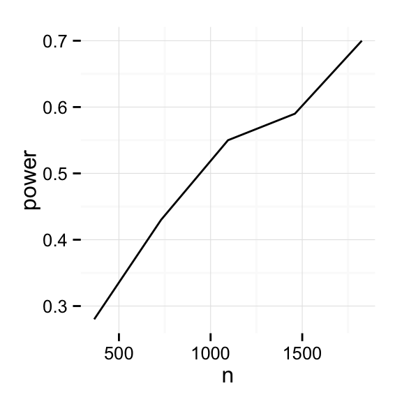

```
##      n power
## 1  365  0.28
## 2  730  0.43
## 3 1095  0.55
## 4 1460  0.59
## 5 1825  0.70
```

```r
power_calc(varying = "n", values = c(365 * (1:5)),
           n_sims = 100, model = "spline_mod", rr = 1.003, plot = TRUE)
```

Here are some examples of varying the relative risk, `r`:

```r
power_calc(varying = "rr", values = c(1.002, 1.005, 1.01, 1.02, 1.03, 1.05, 1.1),
           n_sims = 50, model = "spline_mod", n = 365 * 5)
```

```
##      rr power
## 1 1.002  0.46
## 2 1.005  0.98
## 3 1.010  1.00
## 4 1.020  1.00
## 5 1.030  1.00
## 6 1.050  1.00
## 7 1.100  1.00
```

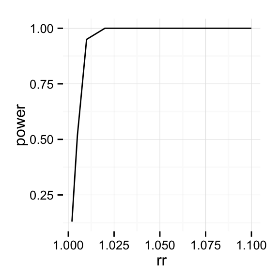

```
##      rr power
## 1 1.002  0.13
## 2 1.005  0.52
## 3 1.010  0.95
## 4 1.020  1.00
## 5 1.030  1.00
## 6 1.050  1.00
## 7 1.100  1.00
```

```r
power_calc(varying = "rr", values = c(1.002, 1.005, 1.01, 1.02, 1.03, 1.05, 1.1),
           n_sims = 100, model = "spline_mod", n = 365, plot = TRUE)
```

Here are some examples of varying the baseline mortality rate, `lambda`:

```r
power_calc(varying = "lambda", values = c(1, 5, 10, 25, 50, 75, 100),
           n_sims = 50, model = "spline_mod", n = 365 * 5, rr = 1.02)
```

```
##   lambda power
## 1      1  0.38
## 2      5  0.96
## 3     10  1.00
## 4     25  1.00
## 5     50  1.00
## 6     75  1.00
## 7    100  1.00
```

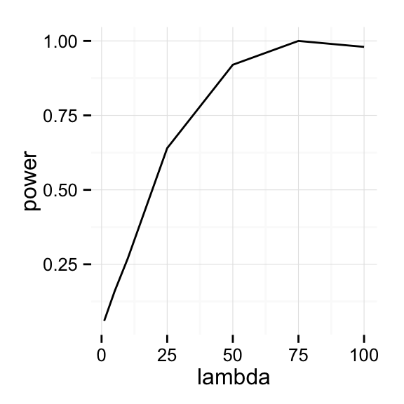

```
##   lambda power
## 1      1  0.06
## 2      5  0.16
## 3     10  0.27
## 4     25  0.64
## 5     50  0.92
## 6     75  1.00
## 7    100  0.98
```

```r
power_calc(varying = "lambda", values = c(1, 5, 10, 25, 50, 75, 100),
           n_sims = 100, model = "spline_mod", n = 365 * 5, rr = 1.005, plot = TRUE)
```

I can compare power from different models using the same data parameters (i.e., sample size, relative risk, etc.) for these:

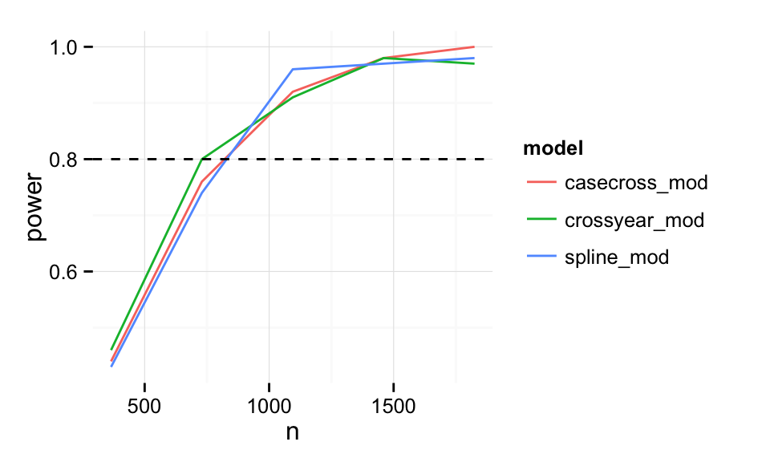

```r
for(model in c("spline_mod", "casecross_mod", "crossyear_mod")){
        df_mod <- power_calc(varying = "n", values = c(365 * (1:5)),
                             n_sims = 100, model = "spline_mod", rr = 1.005)
        df_mod$model <- model
        if(model == "spline_mod"){
                df <- df_mod
        } else {
                df <- rbind(df, df_mod)
        }
}
df$model <- factor(df$model)

ggplot(df, aes(x = n, y = power, color = model)) +
        geom_line() +
        theme_minimal() +
        geom_hline(aes(yintercept = 0.8), linetype = 2)
```

## References

Bateson, Thomas F, and Joel Schwartz. 1999. “Control for Seasonal Variation and Time Trend in Case-Crossover Studies of Acute Effects of Environmental Exposures.” *Epidemiology* 10 (5). LWW: 539–44.

Butland, Barbara K, Ben Armstrong, Richard W Atkinson, Paul Wilkinson, Mathew R Heal, Ruth M Doherty, and Massimo Vieno. 2013. “Measurement Error in Time-Series Analysis: A Simulation Study Comparing Modelled and Monitored Data.” *BMC Medical Research Methodology* 13 (1). BioMed Central Ltd: 136.

Figueiras, Adolfo, Eduardo Carracedo-Martinez, Marc Saez, and Margarita Taracido. 2005. “Analysis of Case-Crossover Designs Using Longitudinal Approaches: A Simulation Study.” *Epidemiology* 16 (2). LWW: 239–46.

Wang, Shirley V, Brent A Coull, Joel Schwartz, Murray A Mittleman, and Gregory A Wellenius. 2011. “Potential for Bias in Case-Crossover Studies with Shared Exposures Analyzed Using SAS.” *American Journal of Epidemiology* 174 (1). Oxford Univ Press: 118–24.